# Statistical inference - GSS survey analysis: Part 2 - Numerical data

Gender pay gap

Anna Loznevaia

2021-11-29

```r
knitr::opts_chunk$set( warning=FALSE, message=FALSE)
```

## Setup

### Load packages

```r
library(ggplot2)
library(dplyr)
library(tidyr)
library(survey)
library(srvyr)
library(questionr)
library(scales)
```

Part 1 - Inference on categorical data - health inequity 2021 https://github.com/Myoth13/GSS/blob/main/GSS_health_inequity_2021.html

### Load data

I’ve uploaded a cross-sectional survey file from GSS web site [<https://gss.norc.org/get-the-data/stata/>](https://gss.norc.org/get-the-data/stata/) and loaded the data to a DB (transfer script https://github.com/Myoth13/GSS/blob/main/DB_transfer.R). For the purpose of replicability of this project I created three light separate data files which can be easily downloaded (script for extracting data - https://github.com/Myoth13/GSS/blob/main/DB_extract.R) - two for the years prior 2020 (categorical and numerical inference) and one for the year 2021.

```r
load("gss_num.RData")
```

## Part 1: Data

The General Social Survey (GSS) is a nationally representative survey of adults in the United States conducted since 1972. The GSS collects data on contemporary American society in order to monitor and explain trends in opinions, attitudes and behaviors. The GSS has adapted questions from earlier surveys, thereby allowing researchers to conduct comparisons for up to 80 years. More information can be found on the web site of the GSS project https://gss.norc.org/About-The-GSS

GSS collects data using multi-stage survey design, which needs to be considered in order to generalize to the whole US population. To make my results **generalizable** I’m going to use the survey analysis library https://cran.r-project.org/web/packages/survey/index.html

This is observational study so only **correlational inference** can be made.

This particular dataset is not very good for analyzing numerical data - the study design intended to be categorical based (opinions, attitudes and behaviours trends). So even supposed to be numerical data like respondent’s income is originally collected as categorical data and then post processed which imply inevitable loss of information. And second - the dataset is not large enough for in-depth (based on many sub-variables) analysis and inference.

## Part 2: Research question

#### Gender pay gap

According to Bureau of Labor Statistics data, in 2020, women’s annual earnings were 82.3% of men’s, and the gap is even wider for many women of color. Though women only made 57 cents per dollar earned by men in 1973 when this [Department of Labor PSA](https://www.youtube.com/watch?v=n00xZ_mKQgk%5d) was made, progress has stalled and we’re still far from closing the pay gap.

[Compared with white men with the same education](https://www.bls.gov/cps/demographics.htm#education), Black and Latina women with only a bachelor’s degree have the largest gap at 65%, and Black women with advanced degrees earn 70% of what white men with advanced degrees earn. Educational attainment is not enough to close gender earnings gaps. In fact, most women with advanced degrees earn less than white men, on average, with only a bachelor’s degree.

Unfortunately, the pandemic stalled gains made toward closing the pay gap, and layoffs and a lack of child care have forced many women out of the workforce entirely. In February 2021, women’s labor force participation rate was 55.8% – the same rate as April 1987. And women of color and those working in low-wage occupations [have been the most impacted](https://www.youtube.com/watch?v=xyX1cjxCG7g).

From https://blog.dol.gov/2021/03/19/5-facts-about-the-state-of-the-gender-pay-gap

I would like to see the general yearly dynamic in the gender pay gap as well as the influence of some other factors such as class, race and age on this dynamic. In my analysis I tried to select variables with the maximum available information across the dataset.

- **conrinc**

> Inflation-adjusted personal income.

> Notes: Income variables (INCOME, RINCOM77, RINCOM82, RINCOM86, RINCOM91) are recoded in six-digit numbers and converted to 2000 dollars. The collapsed numbers above are for convenience of display only. Since this variable is based on categorical data, **income is not continuous**, but based on categorical mid-points and imputations. For details see GSS Methodological Report No. 101.

The data is not available for 2021.

- **sex**

> The variable SEX in face-to-face interviews, interviewers traditionally coded SEX based on interviewer observation
- **degree**

> Respondent’s degree
- **class**

> If you were asked to use one of four names for your social class, which would you say you belong in: the lower class, the working class, the middle class, or the upper class?
- **race**

> What race do you consider yourself?
- **age_group**

arbitrary derivative from the variable `age`

> Respondent’s age

## Part 3: Exploratory data analysis

**Missing data**: 2010 data has no real information on `conrinc` variable, so I’ve decided not to use it in the analysis. Year 2021 has no `conrinc` variable.

```r
gss_num %>%
  filter(year==2010,!is.na(conrinc)) %>%
  select(conrinc) %>%
  summary()
```

```
##     conrinc
##  Min.   :145100
##  1st Qu.:145100
##  Median :145100
##  Mean   :145100
##  3rd Qu.:145100
##  Max.   :145100
```

**Survey design**

```r
gss_num_design <-svydesign(id = ~vpsu,
                           strata = ~vstrat,
                           data = subset(gss_num, !is.na(conrinc) & year!=2010
                                         & class!="no class"),
                           weights = ~wtssall,
                           nest = TRUE)

#removing empty label for class = "no class"
gss_num_design <- update(gss_num_design,class=droplevels(class))

#requred for this particular design
options(survey.lonely.psu="remove")
```

I’m going to create object using `srvyr` library to use lazy tidyverse syntax whenever I want to

```r
gss_num_srvyr_design <- as_survey(gss_num_design)
```

### Income distribution

Compare weighted and unweighted distribution

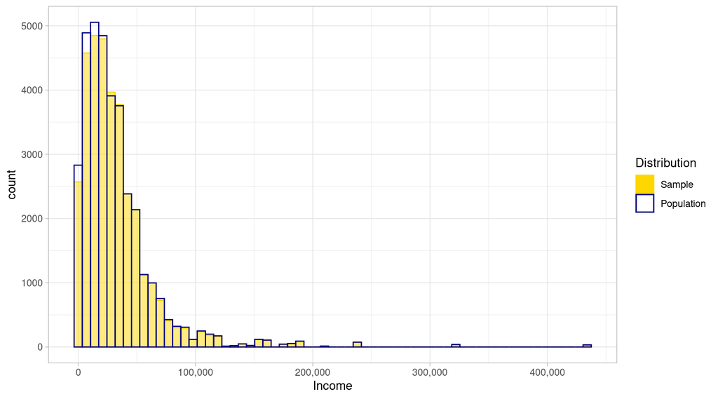

```r
# Create a weighted histogram with ggplot
gss_num %>%
  na.omit() %>%
  ggplot() +
    theme_light() +
    geom_histogram( aes(x=conrinc,color = "Sample",fill = "Sample"),
                    binwidth = 7000, alpha=0.5) +
    geom_histogram( aes(x=conrinc,weight=wtssall,color = "Population",fill = "Population"),
                    binwidth = 7000) +
    labs(x = "Income") +
    scale_color_manual(name = "Distribution",
                      values = c(
                        "Sample" = "gold",
                        "Population" = "navy"
                      )) +
    scale_fill_manual(name = "Distribution",
                      values = c(
                        "Sample" = "gold",
                        "Population" = "transparent"
                      )) +
  scale_x_continuous(labels = comma)
```

There is a noticeable difference between weighted and unweighted distribution. Without accounting for this difference results will be biased and variance calculated incorrectly, which can result in the wrong inference.

**Summary statistics**

```r
summary(gss_num$conrinc)
```

```
##     Min.  1st Qu.   Median     Mean  3rd Qu.     Max.     NA's
##    350.5  12447.5  24882.0  32338.2  40757.0 434612.4    24345
```

Distribution is very skewed. I would prefer to use median whenever possible.

### **I**ncome distribution by gender

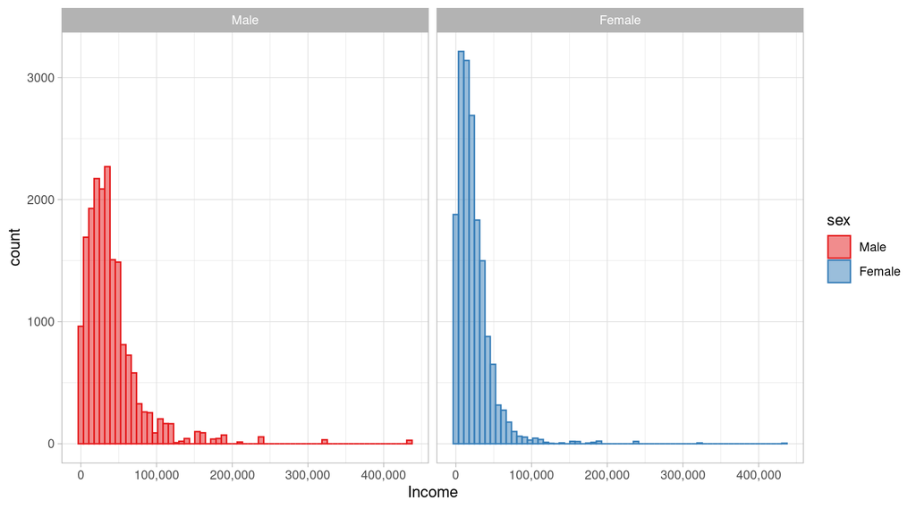

```r
gss_num_srvyr_design %>%
  ggsurvey() +
    theme_light() +
    geom_histogram( aes(x=conrinc,color = sex,fill = sex), binwidth = 7000, alpha=0.5) +
    labs(x = "Income") +
    scale_x_continuous(labels = comma) +
    scale_color_brewer(palette = "Set1")+
    scale_fill_brewer(palette = "Set1") +
    facet_wrap(~sex)
```

### Survey-weighted medians

#### Quantiles with 95% CI

```r
svyquantile(x = ~conrinc,
            design = gss_num_design,
            na.rm = TRUE,
            quantiles = c(0.01, 0.25, 0.5, 0.75,0.99))
```

```
## $conrinc
##       quantile ci.2.5  ci.97.5         se
## 0.01    535.00    535    587.0   13.25783
## 0.25  12008.75  11763  12077.0   80.05690
## 0.5   24359.00  24155  24805.0  165.72288
## 0.75  40645.00  40124  41223.0  280.19915
## 0.99 160964.00 160964 182695.9 5540.73039
##
## attr(,"hasci")
## [1] TRUE
## attr(,"class")
## [1] "newsvyquantile"
```

For `survey.design` objects the default is `interval.type="Wald"`. A 95% Wald confidence interval is constructed for the proportion below the estimated quantile. The inverse of the estimated CDF is used to map this to a confidence interval for the quantile.

#### By gender

- Survey-weighted median income by `sex`

```r
# Compute the survey-weighted medians by sex
svyby(formula = ~conrinc,
          by = ~sex,
          design = gss_num_design,
          FUN = svyquantile,
          na.rm = TRUE,
          quantiles = 0.5,
      )
```

```
##           sex conrinc se.conrinc
## Male     Male   32273   312.3000
## Female Female   18236   205.7004
```

Median income between genders differs. Variance is homogeneous across the groups.

- Survey-weighted median income by `sex` and `year` with 95% CI

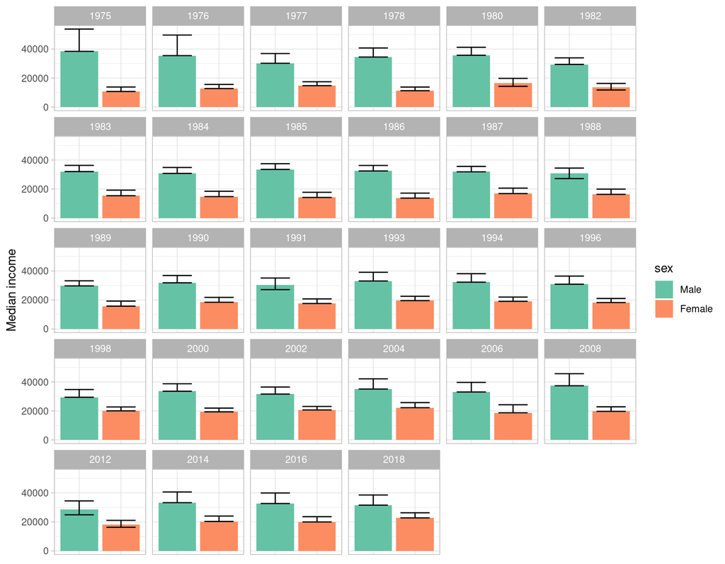

```r
out_s <- svyby(formula = ~conrinc,
                    by = ~year+sex,
                    design = gss_num_design,
                    FUN = svyquantile,
                    quantiles=0.5,
                    na.rm = TRUE,
                    ci=TRUE, vartype="ci"
)

# Construct a bar plot of average income by gender
out_s %>%
  ggplot() +
    aes(x = sex, y = conrinc, ymin = ci_l, ymax = ci_u, fill = sex) +
    geom_col() +
    geom_errorbar(width = 0.7) +
    theme_light() +
    scale_fill_brewer(palette = "Set2")+
    labs(y="Median income") +
    facet_wrap(~year) +
    theme(axis.title.x=element_blank(),
        axis.text.x=element_blank(),
        axis.ticks.x=element_blank())
```

On this bar plot we can see that the median difference is getting smaller with years. To better see the dynamics I made a linear plot

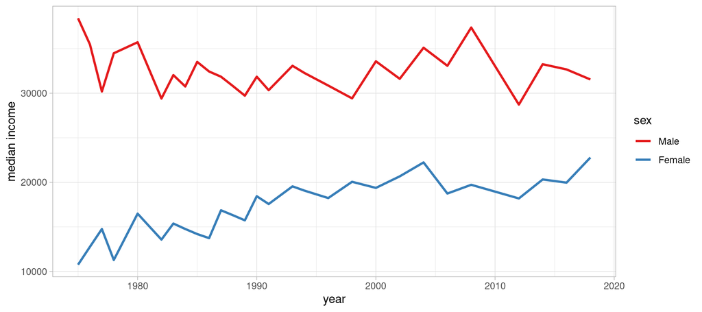

```r
out_s %>%
  ggplot() +
  geom_line(aes(x=year, y=as.numeric(conrinc), color=sex),size=1) +
  theme_light()+
  scale_color_brewer(palette = "Set1") +
  labs(y="median income")
```

#### By gender and degree

If we look at the counts of cases in each group (`sex`+ `year`+`degree`) we can see that there is not enough data to make inference. But anyway it would be interesting to look at the graph.

```r
out_s_d_tot <- svytable(~sex+degree+year, design = gss_num_design)
head(as.data.frame(out_s_d_tot))
```

```
##      sex         degree year     Freq
## 1   Male  < high school 1975 146.3203
## 2 Female  < high school 1975 120.2245
## 3   Male    High school 1975 277.2628
## 4 Female    High school 1975 205.9674
## 5   Male Junior college 1975  18.1737
## 6 Female Junior college 1975   6.5239
```

Graph

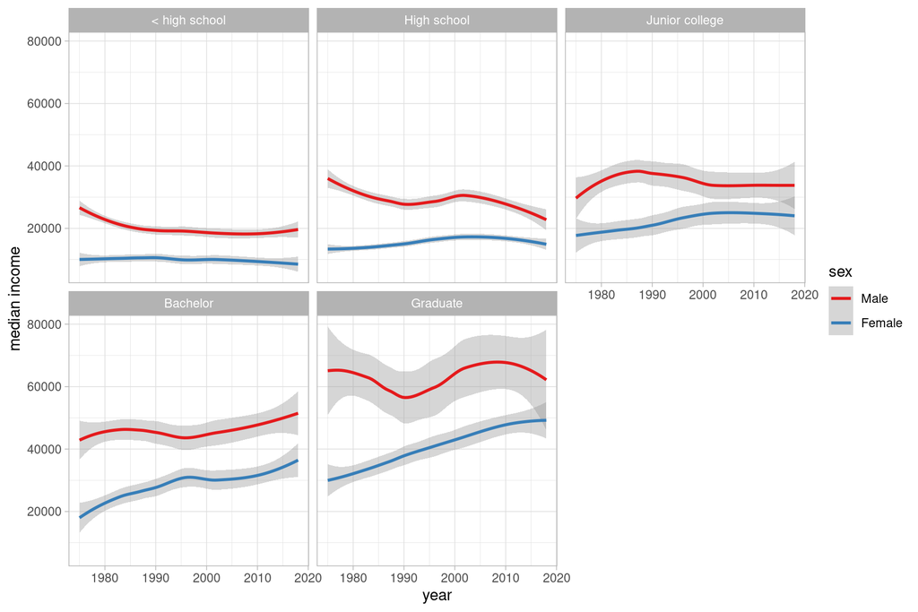

```r
out_s_d <- svyby(formula = ~conrinc,
                    by = ~year+sex+degree,
                    design = gss_num_design,
                    FUN = svyquantile,
                    quantiles=0.5,
                    na.rm = TRUE
)

out_s_d %>%
  ggplot() +
    geom_smooth(aes(x=year, y=as.numeric(conrinc), color=sex),size=1) +
    theme_light()+
    scale_color_brewer(palette = "Set1") +
    labs(y="median income") +
    facet_wrap(~degree)
```

We can see that dynamics is not homogeneous across the groups and variance in the graduate male group is too high.

#### By gender and class

If we look at the counts of cases in each group (`sex`+ `year`+`class`) we can see that there is not enough data to make inference.

```r
out_s_cl_tot <- svytable(~sex+class+year, design = gss_num_design)
head(as.data.frame(out_s_cl_tot))
```

```
##      sex         class year     Freq
## 1   Male   lower class 1975  18.1736
## 2 Female   lower class 1975  13.9795
## 3   Male working class 1975 256.2935
## 4 Female working class 1975 211.5591
## 5   Male  middle class 1975 237.1883
## 6 Female  middle class 1975 157.0383
```

Graph

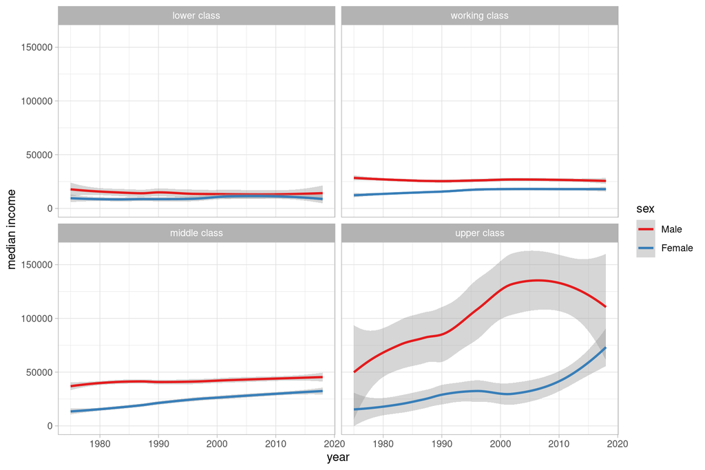

```r
out_s_cl <- svyby(formula = ~conrinc,
                    by = ~year+sex+class,
                    design = gss_num_design,
                    FUN = svyquantile,
                    quantiles=0.5,
                    na.rm = TRUE
)

out_s_cl %>%
  ggplot() +
    geom_smooth(aes(x=year, y=as.numeric(conrinc), color=sex),size=1) +
    theme_light()+
    scale_color_brewer(palette = "Set1") +
    labs(y="median income") +
    facet_wrap(~class)
```

#### By gender and race

If we look at the counts of cases in each group (`sex`+ `year`+`race`) we can see that there is not enough data to make inference.

```r
out_s_r_tot <- svytable(~sex+race+year, design = gss_num_design)
head(as.data.frame(out_s_r_tot))
```

```
##      sex  race year     Freq
## 1   Male White 1975 470.1824
## 2 Female White 1975 334.5802
## 3   Male Black 1975  51.2587
## 4 Female Black 1975  51.2585
## 5   Male Other 1975   0.9320
## 6 Female Other 1975   1.8640
```

Graph

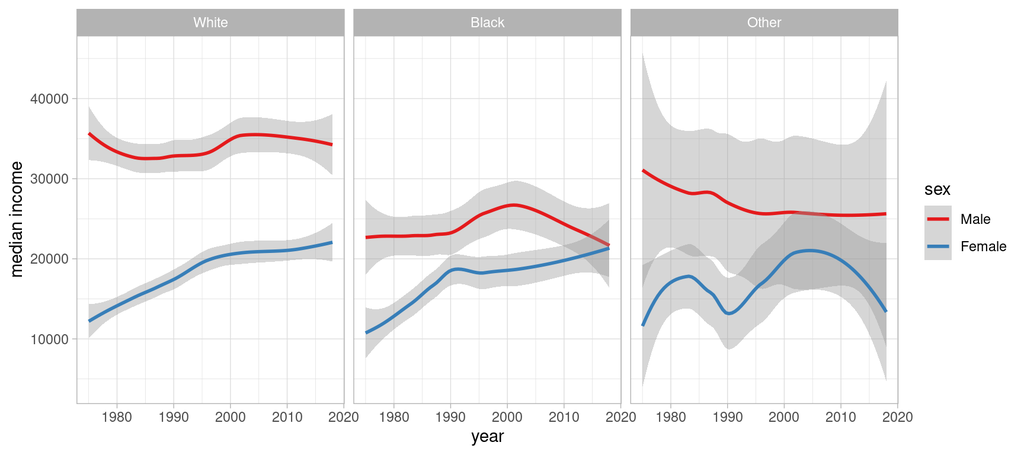

```r
out_s_r <- svyby(formula = ~conrinc,
                    by = ~year+sex+race,
                    design = gss_num_design,
                    FUN = svyquantile,
                    quantiles=0.5,
                    na.rm = TRUE
)

out_s_r %>%
  ggplot() +
    geom_smooth(aes(x=year, y=as.numeric(conrinc), color=sex),size=1) +
    theme_light()+
    scale_color_brewer(palette = "Set1") +
    labs(y="median income") +
    facet_wrap(~race)
```

Way too much variance in the other race group (due to the lack of information in the dataset), but looking at the other two seems like the only privileged group now is white males.

#### By gender and age

If we look at the counts of cases in each group (`sex`+ `year`+`age_group`) we can see that there is not enough data to make inference.

```r
out_s_age_tot <- svytable(~sex+age_group+year, design = gss_num_design)
head(as.data.frame(out_s_age_tot))
```

```
##      sex age_group year     Freq
## 1   Male     18-24 1975  87.6046
## 2 Female     18-24 1975  80.6157
## 3   Male     25-44 1975 227.8710
## 4 Female     25-44 1975 173.3489
## 5   Male     45-64 1975 183.1317
## 6 Female     45-64 1975 116.9622
```

Graph

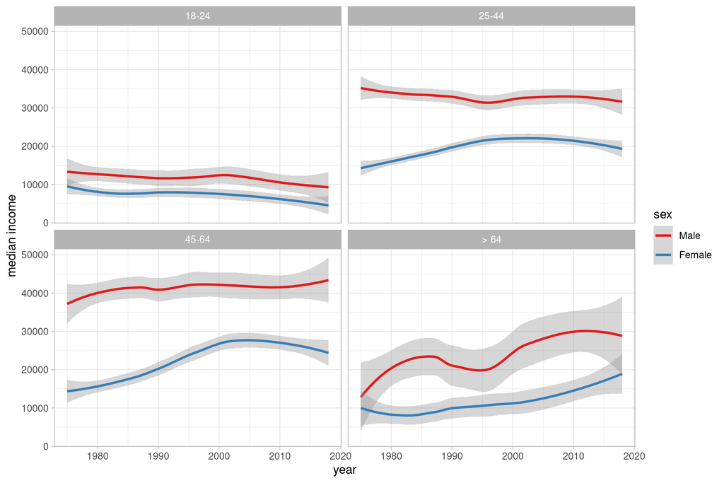

```r
out_s_age <- svyby(formula = ~conrinc,
                    by = ~year+sex+age_group,
                    design = gss_num_design,
                    FUN = svyquantile,
                    quantiles=0.5,
                    na.rm = TRUE
)

out_s_age %>%
  ggplot() +
    geom_smooth(aes(x=year, y=as.numeric(conrinc), color=sex),size=1) +
    theme_light()+
    scale_color_brewer(palette = "Set1") +
    labs(y="median income") +
    facet_wrap(~age_group)
```

Looks like since the 2000th in the middle aged groups things are not getting much better.

## Part 4: Inference

T-test and ANOVA inference is mean-based. Conditions for both are satisfied:

- independence - observations are independent between and within the groups, data is not paired (from GSS survey design), sample size <10% of the population
- distribution of the data within each group is not normal, but sample size is big enough.
- variability across the groups is about equal

### T test

H<sub>0</sub>: there is no difference between mean income of males and females $\mu_{male} = \mu_{female}$

H<sub>1</sub>: there is a difference between mean income of males and females $\mu_{male} \neq \mu_{female}$

```r
##Inference for quantitative data ###Survey-weighted t-test
svyttest(formula = conrinc~sex,
         design = gss_num_design)
```

```
##
##  Design-based t-test
##
## data:  conrinc ~ sex
## t = -42.789, df = 2079, p-value < 2.2e-16
## alternative hypothesis: true difference in mean is not equal to 0
## 95 percent confidence interval:
##  -17758.02 -16201.58
## sample estimates:
## difference in mean
##           -16979.8
```

### ANOVA

For each of the variable we have a pair of hypotheses

H<sub>0</sub>: there is no difference between mean income $\mu_{1} = \mu_{2} = \mu_{...} =\mu_{i}$

H<sub>1</sub>: there is a difference between mean income $\mu_{1} \neq \mu_{2} \neq \mu_{...} \neq \mu_{i}$

To extract ANOVA table from survey design based model I have to use GLM model first.

```r
# Extracting ANOVA table for income by degree and gender
gss.glm1 <- svyglm(conrinc~sex+degree+race+class+age_group, design=gss_num_design)
atable <- anova(gss.glm1)
atable
```

```
## Anova table:  (Rao-Scott LRT)
## svyglm(formula = conrinc ~ sex, design = gss_num_design)
##                stats       DEff         df  ddf         p
## sex       2.4717e+12 1.3500e+09 1.0000e+00 2079 < 2.2e-16 ***
## degree    5.3613e+12 1.7387e+09 4.0000e+00 2075 < 2.2e-16 ***
## race      9.8708e+10 9.0993e+08 2.0000e+00 2073 < 2.2e-16 ***
## class     1.8170e+12 2.4724e+09 3.0000e+00 2070 < 2.2e-16 ***
## age_group 1.7053e+12 9.4575e+08 3.0000e+00 2066 < 2.2e-16 ***
## ---
## Signif. codes:  0 '***' 0.001 '**' 0.01 '*' 0.05 '.' 0.1 ' ' 1
```

Comparing to generic anova with `weights` parameter

```r
atable2 <- aov(conrinc~degree+sex+race+class+age_group, data = gss_num, weights = wtssall)
summary(atable2)
```

```
##                Df    Sum Sq   Mean Sq F value Pr(>F)
## degree          4 5.530e+12 1.383e+12  1668.6 <2e-16 ***
## sex             1 2.566e+12 2.566e+12  3097.3 <2e-16 ***
## race            2 1.004e+11 5.021e+10    60.6 <2e-16 ***
## class           4 1.851e+12 4.628e+11   558.6 <2e-16 ***
## age_group       3 1.710e+12 5.699e+11   687.9 <2e-16 ***
## Residuals   34244 2.837e+13 8.286e+08
## ---
## Signif. codes:  0 '***' 0.001 '**' 0.01 '*' 0.05 '.' 0.1 ' ' 1
## 25954 observations deleted due to missingness
```

Both variants shows that all variables are significant with p-value approaching zero. Thus we can reject both H<sub>0</sub> hypotheses.